# GenHack 2025 Urban Heat Island Challenge — Berlin Code-First Portfolio Project

**Project type:** geospatial data science / climate analytics / urban analytics  
**Primary tools:** Python, Jupyter, Rasterio, GeoPandas, xarray, pandas, matplotlib  
**Case study:** Berlin, Germany

This notebook is designed as a **complete code-first personal project**, not a word-only report. It converts the GenHack Team 46 work into a reproducible portfolio workflow that can be shown to internship recruiters or research assistant supervisors.

The official GenHack challenge asked teams to explore Urban Heat Islands using **ERA5 temperature data, Sentinel-2 NDVI maps, and ground-station observations**, with evaluation on data integration, visualization, quantitative insight, explanatory modeling, and collaboration. This notebook follows that structure through code.

## 0. Project question

Urban Heat Island (UHI) refers to the pattern where urbanized areas tend to be warmer than surrounding less-developed or greener areas. In this project, I frame the problem as a data integration and measurement task:

> **How can we combine satellite vegetation data, climate reanalysis data, and ground-station observations to measure and explain UHI patterns in Berlin?**

The core logic is:

1. Select a city boundary for Berlin.
2. Use Sentinel-2 NDVI to measure vegetation and built-surface patterns.
3. Use ERA5-Land temperature data to measure spatial and temporal heat patterns.
4. Use ground-station metadata/observations to check local measurement coverage.
5. Define UHI metrics, visualize patterns, and discuss limitations.

```python
# 1. Environment setup
from pathlib import Path
import re
import warnings
warnings.filterwarnings("ignore")

import numpy as np
import pandas as pd
import matplotlib.pyplot as plt
from IPython.display import display, Image, Markdown
from PIL import Image as PILImage

# Optional geospatial / climate packages. The notebook is written so cached sections run
# even when raw data is unavailable.
try:
    import geopandas as gpd
    import rasterio
    from rasterio.mask import mask
    import xarray as xr
    GEO_STACK_AVAILABLE = True
except Exception as e:
    GEO_STACK_AVAILABLE = False
    print("Some geospatial packages are unavailable:", e)

PROJECT_ROOT = Path.cwd().parent if Path.cwd().name == "notebooks" else Path.cwd()
DATA_RAW = PROJECT_ROOT / "data" / "raw"
DATA_PROCESSED = PROJECT_ROOT / "data" / "processed"
FIGURES = PROJECT_ROOT / "figures"

CACHE_NDVI_FIGS = FIGURES / "cached_ndvi"
CACHE_WEEK1_FIGS = FIGURES / "repo_week1"

CITY_NAME = "Berlin"
COUNTRY_CODE = "DEU"
COUNTRY_NAME = "Germany"

print("Project root:", PROJECT_ROOT)
print("Raw data folder:", DATA_RAW)
print("Geospatial stack available:", GEO_STACK_AVAILABLE)
```

```
Project root: /mnt/data/genhack_code_first_project
Raw data folder: /mnt/data/genhack_code_first_project/data/raw
Geospatial stack available: True
```

## 1. Repository inventory and reproducibility check

Before running analysis, I first inspect what exists in the project folder. This step matters because the original GitHub repository intentionally does not include raw datasets. A professional workflow should clearly separate:

- raw data paths,
- cached or saved outputs,
- code modules,
- figures,
- processed outputs.

```python
# 2. Inventory project files
file_rows = []
for p in sorted(PROJECT_ROOT.rglob("*")):
    if p.is_file() and ".ipynb_checkpoints" not in str(p):
        file_rows.append({
            "relative_path": str(p.relative_to(PROJECT_ROOT)),
            "suffix": p.suffix.lower(),
            "size_kb": round(p.stat().st_size / 1024, 1)
        })

inventory = pd.DataFrame(file_rows)
display(inventory.head(20))
print("Total files:", len(inventory))
print(inventory.groupby("suffix")["relative_path"].count().sort_values(ascending=False).head(10))
```

|  | relative_path | suffix | size_kb |
| --- | --- | --- | --- |
| 0 | README.md | .md | 1.6 |
| 1 | data/README.md | .md | 0.6 |
| 2 | docs/ECA_Blend_Exploration_Report.md | .md | 8.8 |
| 3 | docs/Exploratory_Data_Analysis__NDVI.txt | .txt | 2.9 |
| 4 | docs/GADM_Dataset_Exploration_Report.md | .md | 9.3 |
| 5 | docs/README.md | .md | 1.1 |
| 6 | figures/cached_ndvi/NDVI_2019-12-01_2020-03-01... | .png | 172.4 |
| 7 | figures/cached_ndvi/NDVI_2020-03-01_2020-06-01... | .png | 170.4 |
| 8 | figures/cached_ndvi/NDVI_2020-06-01_2020-09-01... | .png | 178.0 |
| 9 | figures/cached_ndvi/NDVI_2020-09-01_2020-12-01... | .png | 176.0 |
| 10 | figures/cached_ndvi/NDVI_2020-12-01_2021-03-01... | .png | 177.7 |
| 11 | figures/cached_ndvi/NDVI_2021-03-01_2021-06-01... | .png | 168.9 |
| 12 | figures/cached_ndvi/NDVI_2021-06-01_2021-09-01... | .png | 174.5 |
| 13 | figures/cached_ndvi/NDVI_2021-09-01_2021-12-01... | .png | 171.4 |
| 14 | figures/cached_ndvi/NDVI_2021-12-01_2022-03-01... | .png | 178.0 |
| 15 | figures/cached_ndvi/NDVI_2022-03-01_2022-06-01... | .png | 165.6 |
| 16 | figures/cached_ndvi/NDVI_2022-06-01_2022-09-01... | .png | 175.9 |
| 17 | figures/cached_ndvi/NDVI_2022-09-01_2022-12-01... | .png | 174.3 |
| 18 | figures/cached_ndvi/NDVI_2022-12-01_2023-03-01... | .png | 175.8 |
| 19 | figures/cached_ndvi/NDVI_2023-03-01_2023-06-01... | .png | 169.6 |

```
Total files: 42
suffix
.png      26
.py        8
.md        5
.txt       2
.ipynb     1
Name: relative_path, dtype: int64
```

```python
# 3. Check whether raw data is available for full rerun
expected_raw = {
    "GADM boundaries": DATA_RAW / "gadm_410_europe.gpkg",
    "ECA station metadata": DATA_RAW / "ECA_blend_tx" / "stations.txt",
    "Sentinel-2 NDVI directory": DATA_RAW / "sentinel_ndvi",
    "ERA5 directory": DATA_RAW / "derived-era5-land-daily-statistics",
}

raw_status = []
for name, path in expected_raw.items():
    raw_status.append({"raw_dataset": name, "path": str(path), "exists": path.exists()})
raw_status = pd.DataFrame(raw_status)
display(raw_status)

if not raw_status["exists"].all():
    print("Full raw-data rerun is not possible yet. The notebook will still run cached-output sections and provides complete code for full rerun once raw data is placed in data/raw/.")
```

|  | raw_dataset | path | exists |
| --- | --- | --- | --- |
| 0 | GADM boundaries | /mnt/data/genhack_code_first_project/data/raw/... | False |
| 1 | ECA station metadata | /mnt/data/genhack_code_first_project/data/raw/... | False |
| 2 | Sentinel-2 NDVI directory | /mnt/data/genhack_code_first_project/data/raw/... | False |
| 3 | ERA5 directory | /mnt/data/genhack_code_first_project/data/raw/... | False |

```
Full raw-data rerun is not possible yet. The notebook will still run cached-output sections and provides complete code for full rerun once raw data is placed in data/raw/.
```

## 2. Data sources and why Berlin was selected

The project uses three types of data.

**GADM administrative boundaries** define the Berlin study area. This is necessary because climate and satellite rasters cover wide regions, while the analysis needs a city-scale mask.

**Sentinel-2 NDVI rasters** measure vegetation conditions. NDVI is useful because low vegetation and impervious surfaces are important explanatory factors for urban heat.

**ERA5-Land temperature data** provides gridded daily climate variables. ERA5 can show spatial heat patterns even when ground stations are sparse.

**Ground-station observations** provide local weather-station information and help evaluate how observational coverage relates to the gridded ERA5 data.

Berlin is a strong case study because it is a large European city with dense built areas, parks, water bodies, and surrounding lower-density regions. This gives enough land-surface contrast for a meaningful UHI analysis.

## 3. Boundary workflow: selecting Berlin from GADM

```python
# 4. Boundary functions
if GEO_STACK_AVAILABLE:
    def load_gadm(gadm_path):
        """Load GADM Europe administrative boundaries."""
        return gpd.read_file(gadm_path)

    def select_city_boundary(gadm_gdf, country_code="DEU", city_name="Berlin"):
        """Select and dissolve a city boundary from GADM.

        The GADM hierarchy differs by country, so I search multiple NAME_* levels.
        """
        candidates = []
        for col in ["NAME_1", "NAME_2", "NAME_3", "NAME_4", "NAME_5"]:
            if col in gadm_gdf.columns:
                q = gadm_gdf[(gadm_gdf.get("GID_0") == country_code) & (gadm_gdf[col] == city_name)]
                if len(q) > 0:
                    candidates.append((col, q))
        if not candidates:
            raise ValueError(f"Could not find {city_name} in GADM for {country_code}.")
        match_level, city = candidates[0]
        print(f"Matched city at GADM level: {match_level}; records: {len(city)}")
        return city.dissolve()
else:
    print("Geo stack unavailable; skipping boundary functions.")
```

```python
# 5. Load Berlin boundary if raw GADM exists
GADM_PATH = DATA_RAW / "gadm_410_europe.gpkg"

if GEO_STACK_AVAILABLE and GADM_PATH.exists():
    gadm = load_gadm(GADM_PATH)
    berlin_gdf = select_city_boundary(gadm, COUNTRY_CODE, CITY_NAME)
    DATA_PROCESSED.mkdir(parents=True, exist_ok=True)
    berlin_gdf.to_file(DATA_PROCESSED / "berlin_boundary.geojson", driver="GeoJSON")
    print(berlin_gdf.crs)
    ax = berlin_gdf.boundary.plot(figsize=(6, 6), color="black")
    ax.set_title("Berlin boundary from GADM")
    plt.show()
else:
    berlin_gdf = None
    print("GADM raw file not found. Boundary code is ready, but not executed in full mode.")
```

```
GADM raw file not found. Boundary code is ready, but not executed in full mode.
```

## 4. Ground-station workflow: loading and cleaning ECA station metadata

This station pipeline comes from the Team 46 week 1 exploration. It converts station metadata into a geospatial format. The key technical issue is that the original station coordinates use DMS strings such as `+52:31:00`, so they must be converted into decimal degrees before mapping or joining.

```python
# 6. ECA station loading functions
if GEO_STACK_AVAILABLE:
    def dms_to_decimal(dms_str):
        """Convert DMS coordinate string (+DD:MM:SS) to decimal degrees."""
        dms_str = str(dms_str).strip()
        sign = 1 if dms_str[0] == "+" else -1
        degrees, minutes, seconds = [float(x) for x in dms_str[1:].split(":")]
        return sign * (degrees + minutes / 60 + seconds / 3600)

    def load_eca_stations(stations_filepath):
        """Load ECA&D station metadata and convert to GeoDataFrame."""
        stations_df = pd.read_csv(stations_filepath, skiprows=17, skipinitialspace=True).rename(columns=str.strip)
        stations_df["LAT_decimal"] = stations_df["LAT"].apply(dms_to_decimal)
        stations_df["LON_decimal"] = stations_df["LON"].apply(dms_to_decimal)
        return gpd.GeoDataFrame(
            stations_df,
            geometry=gpd.points_from_xy(stations_df["LON_decimal"], stations_df["LAT_decimal"]),
            crs="EPSG:4326",
        )

    def select_stations_within_city(stations_gdf, city_gdf):
        """Return stations located inside the selected city boundary."""
        city = city_gdf.to_crs(stations_gdf.crs)
        geom = city.geometry.unary_union
        return stations_gdf[stations_gdf.within(geom)].copy()
```

```python
# 7. Run station pipeline if raw station metadata exists
ECA_STATIONS_PATH = DATA_RAW / "ECA_blend_tx" / "stations.txt"

if GEO_STACK_AVAILABLE and ECA_STATIONS_PATH.exists():
    stations_gdf = load_eca_stations(ECA_STATIONS_PATH)
    display(stations_gdf.head())
    print("Total stations:", len(stations_gdf))
    print("Countries:", stations_gdf["CN"].nunique())
    if berlin_gdf is not None:
        berlin_stations = select_stations_within_city(stations_gdf, berlin_gdf)
        print("Stations inside Berlin:", len(berlin_stations))
        ax = berlin_gdf.boundary.plot(figsize=(7, 7), color="black")
        berlin_stations.plot(ax=ax, markersize=20, color="red")
        ax.set_title("ECA stations inside Berlin")
        plt.show()
else:
    print("Station raw file not found. Showing cached week 1 outputs instead.")
```

```
Station raw file not found. Showing cached week 1 outputs instead.
```

```
Cached week 1 figures: 9
```

**Distribution visualizations.png**

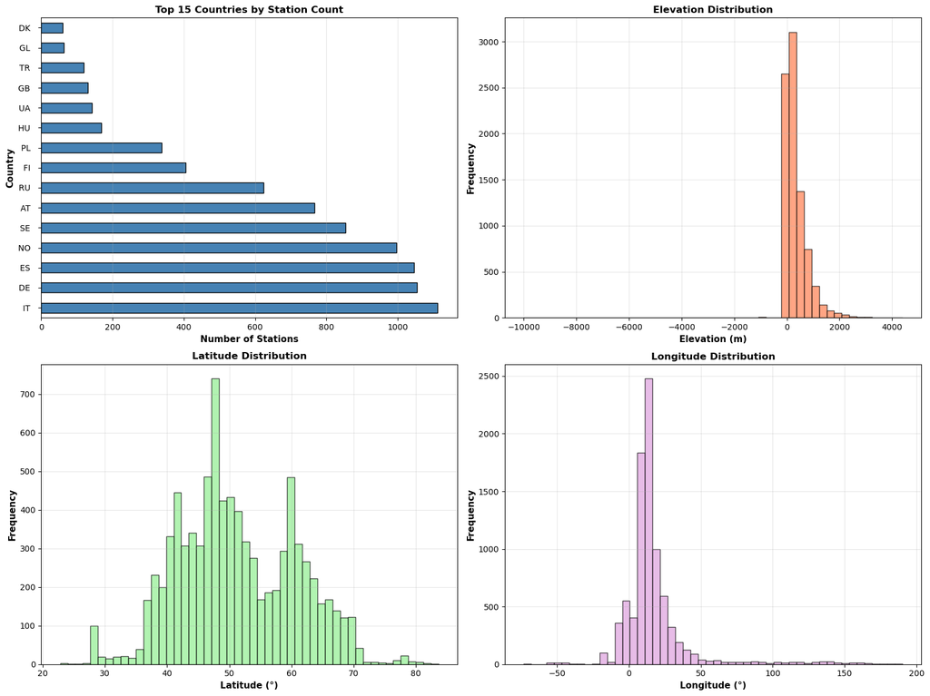

**ECA Blend Weather Stations - Geographic Distribution.png**

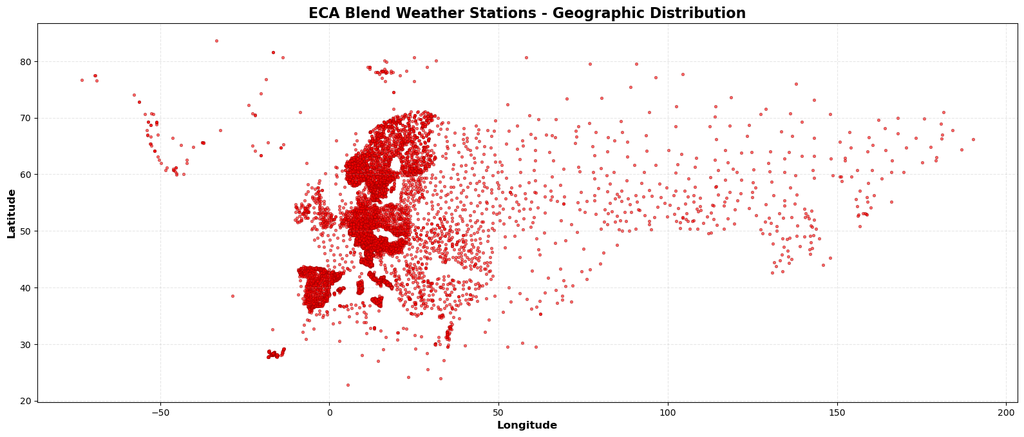

**Weather Stations - Colored by Elevation.png**

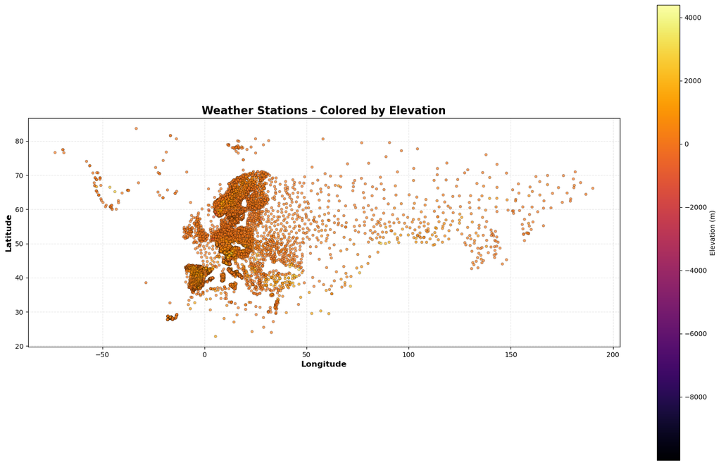

**Administrative Hierarchy Levels - Unique Units Count.png**

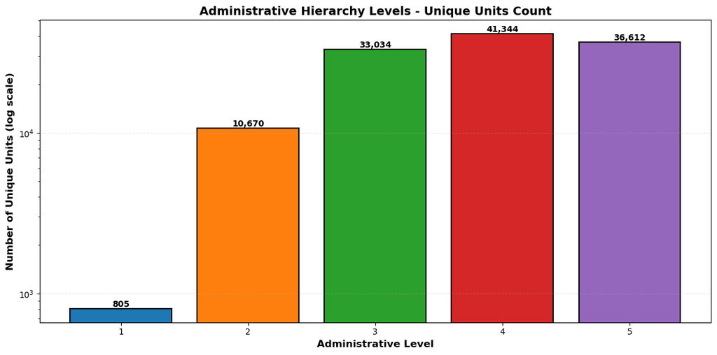

**GADM Europe - All Administrative Boundaries (Level 5).png**

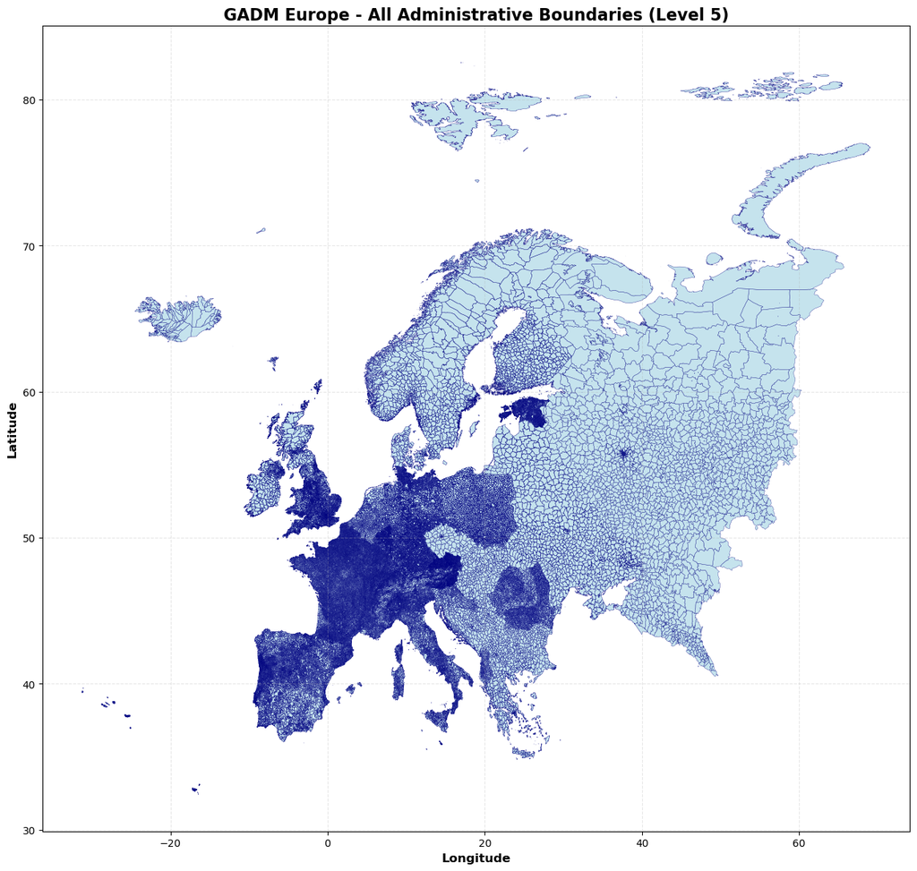

**GADM Europe - Country Boundaries (Level 0).png**

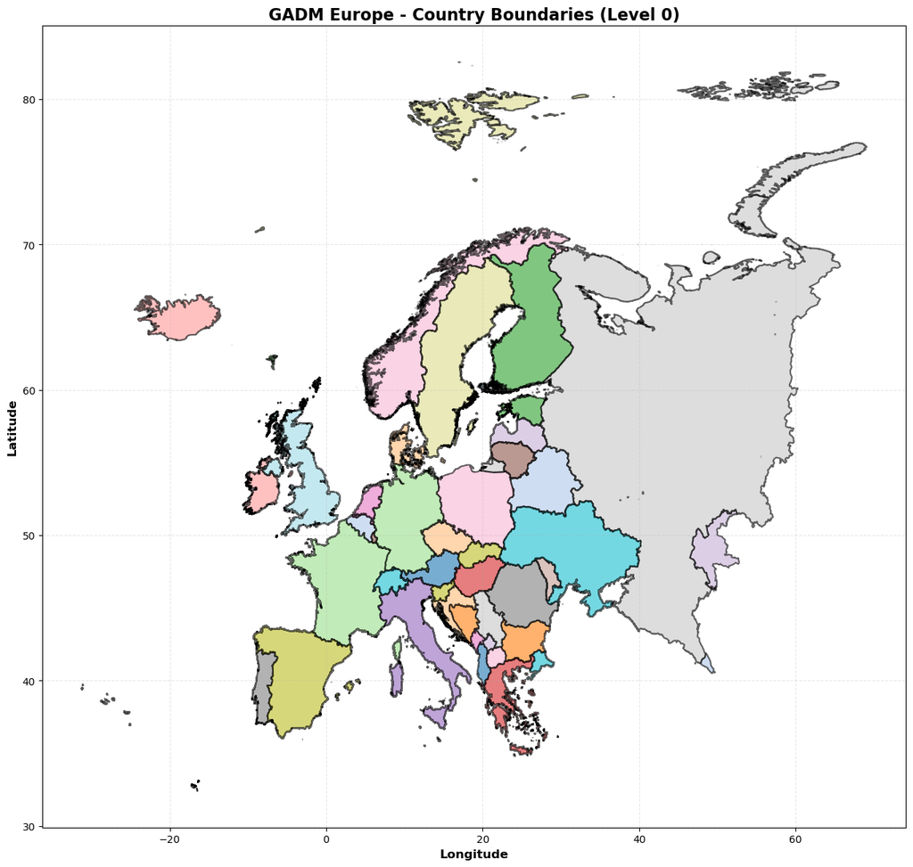

```python
# 8. Display cached station/GADM exploratory figures from the uploaded repo
cached_week1_images = sorted(CACHE_WEEK1_FIGS.rglob("*.png"))
print("Cached week 1 figures:", len(cached_week1_images))
for img in cached_week1_images[:6]:
    display(Markdown(f"**{img.name}**"))
    display(Image(filename=str(img), width=650))
```

## 5. NDVI workflow: Sentinel-2 vegetation analysis

NDVI measures vegetation greenness using satellite reflectance. In this project, NDVI is used as an explanatory layer for UHI because greener surfaces are often cooler, while dense built surfaces tend to store heat.

and nodata is stored as `255`. The code below converts the raster into real NDVI values and masks it to Berlin.

```python
# 9. NDVI date parsing and catalog functions

def quarter_to_timeperiod(year: int, quarter: int) -> str:
    """Convert GenHack quarter convention into Sentinel-2 NDVI filename date range."""
    if quarter == 1:
        return f"{year-1}-12-01_{year}-03-01"
    if quarter == 2:
        return f"{year}-03-01_{year}-06-01"
    if quarter == 3:
        return f"{year}-06-01_{year}-09-01"
    if quarter == 4:
        return f"{year}-09-01_{year}-12-01"
    raise ValueError("quarter must be 1, 2, 3, or 4")


def parse_ndvi_filename(path):
    """Parse a cached NDVI filename or raw NDVI GeoTIFF filename."""
    p = Path(path)
    match = re.search(r"(20\d{2}-\d{2}-\d{2})_(20\d{2}-\d{2}-\d{2})", p.name)
    if not match:
        return None
    start, end = match.groups()
    return {
        "path": p,
        "start": pd.to_datetime(start),
        "end": pd.to_datetime(end),
        "period": f"{start} to {end}",
        "year": pd.to_datetime(end).year,
        "season_index": pd.to_datetime(start).month,
    }


def build_ndvi_catalog(paths):
    rows = [parse_ndvi_filename(p) for p in paths]
    rows = [r for r in rows if r is not None]
    return pd.DataFrame(rows).sort_values("start").reset_index(drop=True) if rows else pd.DataFrame()
```

```python
# 10. Build a catalog of cached NDVI outputs from the uploaded repo
cached_ndvi_paths = sorted(CACHE_NDVI_FIGS.glob("NDVI_*.png"))
ndvi_fig_catalog = build_ndvi_catalog(cached_ndvi_paths)

display(ndvi_fig_catalog.head())
print("Number of cached quarterly NDVI figures:", len(ndvi_fig_catalog))
```

|  | path | start | end | period | year | season_index |
| --- | --- | --- | --- | --- | --- | --- |
| 0 | /mnt/data/genhack_code_first_project/figures/c... | 2019-12-01 | 2020-03-01 | 2019-12-01 to 2020-03-01 | 2020 | 12 |
| 1 | /mnt/data/genhack_code_first_project/figures/c... | 2020-03-01 | 2020-06-01 | 2020-03-01 to 2020-06-01 | 2020 | 3 |
| 2 | /mnt/data/genhack_code_first_project/figures/c... | 2020-06-01 | 2020-09-01 | 2020-06-01 to 2020-09-01 | 2020 | 6 |
| 3 | /mnt/data/genhack_code_first_project/figures/c... | 2020-09-01 | 2020-12-01 | 2020-09-01 to 2020-12-01 | 2020 | 9 |
| 4 | /mnt/data/genhack_code_first_project/figures/c... | 2020-12-01 | 2021-03-01 | 2020-12-01 to 2021-03-01 | 2021 | 12 |

```
Number of cached quarterly NDVI figures: 16
```

```python
# 11. Inspect cached NDVI image dimensions and file sizes
image_meta = []
for p in cached_ndvi_paths:
    with PILImage.open(p) as im:
        image_meta.append({
            "filename": p.name,
            "width": im.width,
            "height": im.height,
            "size_kb": round(p.stat().st_size / 1024, 1),
        })
image_meta = pd.DataFrame(image_meta)
display(image_meta.head())
```

|  | filename | width | height | size_kb |
| --- | --- | --- | --- | --- |
| 0 | NDVI_2019-12-01_2020-03-01.png | 534 | 418 | 172.4 |
| 1 | NDVI_2020-03-01_2020-06-01.png | 534 | 418 | 170.4 |
| 2 | NDVI_2020-06-01_2020-09-01.png | 534 | 418 | 178.0 |
| 3 | NDVI_2020-09-01_2020-12-01.png | 534 | 418 | 176.0 |
| 4 | NDVI_2020-12-01_2021-03-01.png | 534 | 418 | 177.7 |

Cached output: NDVI Mean Over Time

[figure not shown]

```python
# 12. Display the repository's NDVI mean-over-time figure if available
mean_fig = CACHE_NDVI_FIGS / "NDVI_Mean_OverTime.png"
if mean_fig.exists():
    display(Markdown("### Cached output: NDVI Mean Over Time"))
    display(Image(filename=str(mean_fig), width=750))
else:
    print("NDVI mean figure not found.")
```

**NDVI_2020-03-01_2020-06-01.png**

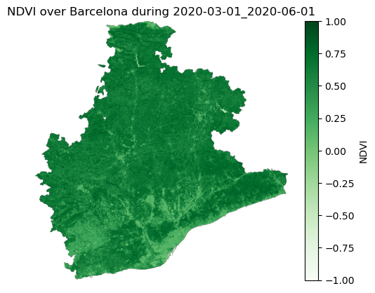

**NDVI_2020-06-01_2020-09-01.png**

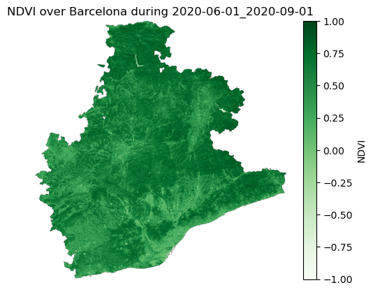

**NDVI_2021-03-01_2021-06-01.png**

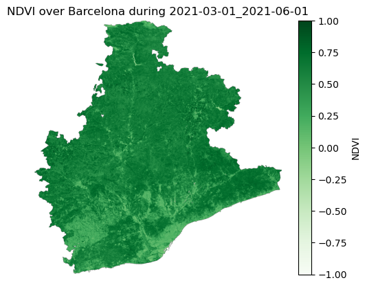

**NDVI_2022-06-01_2022-09-01.png**

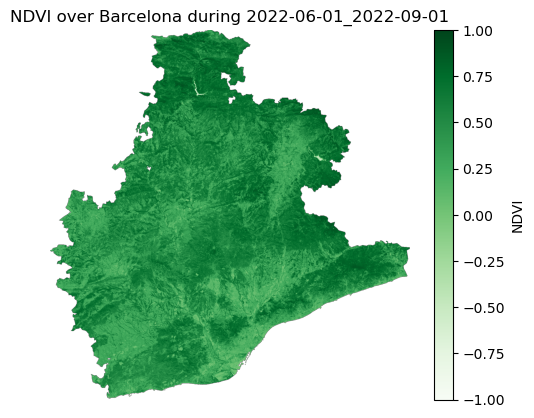

**NDVI_2023-03-01_2023-06-01.png**

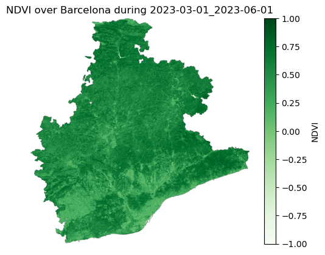

**NDVI_2023-09-01_2023-12-01.png**

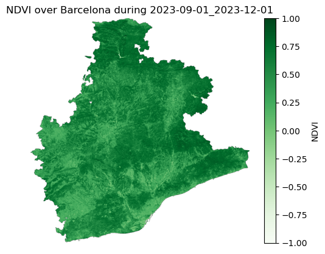

```python
# 13. Display selected quarterly NDVI outputs to show seasonal and yearly patterns
sample_periods = [
    "NDVI_2020-03-01_2020-06-01.png",
    "NDVI_2020-06-01_2020-09-01.png",
    "NDVI_2021-03-01_2021-06-01.png",
    "NDVI_2022-06-01_2022-09-01.png",
    "NDVI_2023-03-01_2023-06-01.png",
    "NDVI_2023-09-01_2023-12-01.png",
]
for name in sample_periods:
    p = CACHE_NDVI_FIGS / name
    if p.exists():
        display(Markdown(f"**{name}**"))
        display(Image(filename=str(p), width=650))
```

```python
# 14. Full NDVI raster processing functions; runs when raw .tif files exist
if GEO_STACK_AVAILABLE:
    def convert_ndvi_to_real_scale(ndvi_img, nodata=255):
        """Convert encoded NDVI integer raster to real NDVI [-1, 1]."""
        arr = ndvi_img.astype("float32")
        arr[arr == nodata] = np.nan
        return arr / 254 * 2 - 1

    def clip_ndvi_to_city(filepath, city_gdf):
        """Clip a single NDVI raster to a city boundary."""
        with rasterio.open(filepath) as src:
            city_in_crs = city_gdf.to_crs(src.crs)
            out_img, out_transform = mask(src, city_in_crs.geometry, crop=True)
            out_meta = src.meta.copy()
            out_meta.update({
                "height": out_img.shape[1],
                "width": out_img.shape[2],
                "transform": out_transform,
            })
            ndvi = convert_ndvi_to_real_scale(out_img[0], nodata=out_meta.get("nodata", 255))
            return ndvi, out_meta

    def summarize_ndvi_array(ndvi, label=None):
        """Compute summary metrics from a clipped NDVI raster."""
        return {
            "label": label,
            "n_pixels": int(np.isfinite(ndvi).sum()),
            "mean_ndvi": float(np.nanmean(ndvi)),
            "median_ndvi": float(np.nanmedian(ndvi)),
            "std_ndvi": float(np.nanstd(ndvi)),
            "p10_ndvi": float(np.nanpercentile(ndvi, 10)),
            "p90_ndvi": float(np.nanpercentile(ndvi, 90)),
            "share_dense_veg": float(np.nanmean(ndvi > 0.6)),
            "share_low_veg_or_built": float(np.nanmean(ndvi < 0.2)),
        }

    def process_ndvi_time_series(ndvi_catalog, city_gdf):
        """Clip each NDVI raster to Berlin and calculate quarterly metrics."""
        rows = []
        for _, row in ndvi_catalog.iterrows():
            ndvi, meta = clip_ndvi_to_city(row["path"], city_gdf)
            summary = summarize_ndvi_array(ndvi, row["period"])
            summary.update({"start": row["start"], "end": row["end"], "path": str(row["path"])})
            rows.append(summary)
        return pd.DataFrame(rows).sort_values("start")
```

```python
# 15. Run NDVI pipeline if raw rasters exist
NDVI_RAW_DIR = DATA_RAW / "sentinel_ndvi"
raw_ndvi_paths = sorted(NDVI_RAW_DIR.glob("*.tif")) if NDVI_RAW_DIR.exists() else []

if GEO_STACK_AVAILABLE and berlin_gdf is not None and raw_ndvi_paths:
    ndvi_raw_catalog = build_ndvi_catalog(raw_ndvi_paths)
    ndvi_summary = process_ndvi_time_series(ndvi_raw_catalog, berlin_gdf)
    DATA_PROCESSED.mkdir(exist_ok=True, parents=True)
    ndvi_summary.to_csv(DATA_PROCESSED / "berlin_ndvi_summary.csv", index=False)
    display(ndvi_summary)

    fig, ax = plt.subplots(figsize=(10, 4))
    ax.plot(ndvi_summary["start"], ndvi_summary["mean_ndvi"], marker="o")
    ax.set_title("Berlin Mean NDVI by Quarter")
    ax.set_ylabel("Mean NDVI")
    ax.set_xlabel("Date")
    ax.grid(alpha=0.3)
    plt.show()
else:
    print("Raw NDVI rasters not found, so full NDVI metric table is not generated here.")
```

```
Raw NDVI rasters not found, so full NDVI metric table is not generated here.
```

## 6. ERA5 workflow: temperature data and UHI metric design

ERA5-Land provides gridded climate variables, including 2-meter temperature. For UHI analysis, the key task is to compare urban temperatures with a reference area. There are multiple possible metric definitions.

I define a simple, interpretable metric:

[ UHI_t = T_{urban,t} - T_{reference,t} ]

where `reference` can be a rural ring around the city, a low-density/greener zone, or a surrounding non-urban area. In a full version with raw ERA5 data, the code below can compute daily maximum temperature over Berlin and over a comparison area.

```python
# 16. ERA5 helper functions
if GEO_STACK_AVAILABLE:
    def find_era5_files(era5_dir, variable="2m_temperature", statistic="daily_maximum"):
        era5_dir = Path(era5_dir)
        return sorted(era5_dir.glob(f"*_{variable}_{statistic}.nc"))

    def load_era5(files):
        if len(files) == 0:
            raise FileNotFoundError("No ERA5 NetCDF files found.")
        return xr.open_mfdataset(files, combine="by_coords")

    def kelvin_to_celsius(da):
        return da - 273.15

    def subset_era5_to_city_bbox(ds, city_gdf, lon_name="longitude", lat_name="latitude"):
        minx, miny, maxx, maxy = city_gdf.to_crs("EPSG:4326").total_bounds
        # ERA5 latitude is often descending; this handles the common case.
        return ds.sel({lon_name: slice(minx, maxx), lat_name: slice(maxy, miny)})

    def compute_simple_uhi(urban_temp, reference_temp):
        return urban_temp - reference_temp
```

```python
# 17. Run ERA5 workflow if raw NetCDF files exist
ERA5_DIR = DATA_RAW / "derived-era5-land-daily-statistics"
era5_files = find_era5_files(ERA5_DIR) if GEO_STACK_AVAILABLE and ERA5_DIR.exists() else []
print("ERA5 files found:", len(era5_files))

if GEO_STACK_AVAILABLE and berlin_gdf is not None and era5_files:
    era5_ds = load_era5(era5_files)
    print(era5_ds)
    era5_city = subset_era5_to_city_bbox(era5_ds, berlin_gdf)
    print(era5_city)

    # Example variable name is often 't2m', but this can differ by file.
    candidate_vars = list(era5_city.data_vars)
    print("Available variables:", candidate_vars)
else:
    print("ERA5 raw files not available. ERA5 computation code is included for full rerun.")
```

```
ERA5 files found: 0
ERA5 raw files not available. ERA5 computation code is included for full rerun.
```

## 7. Data integration table

The value of this project is not only making individual plots. The main analytical challenge is integration: each dataset has different spatial resolution, temporal resolution, file format, and meaning.

The target integrated table should have one row per city-period, with columns such as:

- period start/end,
- mean NDVI,
- share of low-vegetation/built pixels,
- daily or quarterly temperature metric,
- UHI intensity,
- station coverage or station difference metrics.

```python
# 18. Example schema for an integrated analysis table
integrated_schema = pd.DataFrame({
    "column": [
        "city", "period_start", "period_end", "mean_ndvi", "share_low_veg_or_built",
        "share_dense_veg", "urban_temp_c", "reference_temp_c", "uhi_intensity_c",
        "n_weather_stations", "era5_station_diff_c"
    ],
    "meaning": [
        "Study city", "Start of NDVI/temperature aggregation window", "End of aggregation window",
        "Average Sentinel-2 NDVI inside city boundary", "Share of pixels with NDVI < 0.2",
        "Share of pixels with NDVI > 0.6", "Mean/max ERA5 temperature in urban area",
        "Mean/max ERA5 temperature in reference area", "Urban minus reference temperature",
        "Number of ECA stations inside/near city", "Difference between ERA5 grid and station observations"
    ]
})
display(integrated_schema)
```

|  | column | meaning |
| --- | --- | --- |
| 0 | city | Study city |
| 1 | period_start | Start of NDVI/temperature aggregation window |
| 2 | period_end | End of aggregation window |
| 3 | mean_ndvi | Average Sentinel-2 NDVI inside city boundary |
| 4 | share_low_veg_or_built | Share of pixels with NDVI < 0.2 |
| 5 | share_dense_veg | Share of pixels with NDVI > 0.6 |
| 6 | urban_temp_c | Mean/max ERA5 temperature in urban area |
| 7 | reference_temp_c | Mean/max ERA5 temperature in reference area |
| 8 | uhi_intensity_c | Urban minus reference temperature |
| 9 | n_weather_stations | Number of ECA stations inside/near city |
| 10 | era5_station_diff_c | Difference between ERA5 grid and station obser... |

```python
# 19. Build integrated table if processed outputs exist
ndvi_summary_path = DATA_PROCESSED / "berlin_ndvi_summary.csv"
if ndvi_summary_path.exists():
    ndvi_summary = pd.read_csv(ndvi_summary_path, parse_dates=["start", "end"])
    integrated = ndvi_summary.copy()
    integrated["city"] = CITY_NAME
    # ERA5 and station metrics would be merged here when processed files exist.
    display(integrated.head())
else:
    print("No processed NDVI summary found yet. Full integrated table will be created after raw data processing.")
```

```
No processed NDVI summary found yet. Full integrated table will be created after raw data processing.
```

## 8. Exploratory modeling framework

A production-level model is not possible without the raw ERA5 and station observation tables, but the modeling design is clear.

Interpretation:

- negative NDVI coefficient: greener periods/areas are associated with lower UHI intensity;
- seasonal effects: UHI differs by season;
- station/elevation controls: reduce bias from weather-station placement.

```python
# 20. Modeling template for the final integrated table
from sklearn.model_selection import train_test_split
from sklearn.metrics import mean_absolute_error, r2_score
from sklearn.ensemble import RandomForestRegressor
from sklearn.linear_model import LinearRegression


def fit_uhi_models(df):
    """Fit baseline linear and random forest models to explain UHI intensity.

    Required columns:
        mean_ndvi, share_low_veg_or_built, share_dense_veg, uhi_intensity_c
    """
    features = ["mean_ndvi", "share_low_veg_or_built", "share_dense_veg"]
    target = "uhi_intensity_c"
    model_df = df.dropna(subset=features + [target]).copy()
    X = model_df[features]
    y = model_df[target]

    if len(model_df) < 8:
        raise ValueError("Not enough rows to train/test models. Add more periods or spatial units.")

    X_train, X_test, y_train, y_test = train_test_split(X, y, test_size=0.25, random_state=42)

    models = {
        "linear_regression": LinearRegression(),
        "random_forest": RandomForestRegressor(n_estimators=300, random_state=42),
    }
    results = []
    fitted = {}
    for name, model in models.items():
        model.fit(X_train, y_train)
        pred = model.predict(X_test)
        results.append({
            "model": name,
            "mae": mean_absolute_error(y_test, pred),
            "r2": r2_score(y_test, pred),
        })
        fitted[name] = model
    return pd.DataFrame(results), fitted

print("Model function ready. It will run after the integrated table includes UHI intensity.")
```

```
Model function ready. It will run after the integrated table includes UHI intensity.
```

```python
# 21. Example of how the model would be run
if 'integrated' in globals() and 'uhi_intensity_c' in integrated.columns:
    metrics, fitted_models = fit_uhi_models(integrated)
    display(metrics)
else:
    print("Model not run because integrated table does not yet include uhi_intensity_c.")
```

```
Model not run because integrated table does not yet include uhi_intensity_c.
```

## 9. Visualization design for final outputs

For a portfolio project, visuals should not only be beautiful. They should answer analytical questions.

Recommended final visuals:

1. Berlin boundary + weather stations.
2. NDVI quarterly maps from 2020–2023.
3. Mean NDVI trend over time.
4. ERA5 temperature map or time series.
5. UHI intensity over time.
6. NDVI vs. UHI relationship.
7. Final summary dashboard with key metrics and limitations.

```python
# 22. Visualization templates
import seaborn as sns


def plot_ndvi_summary(ndvi_summary):
    fig, ax = plt.subplots(figsize=(10, 4))
    ax.plot(ndvi_summary["start"], ndvi_summary["mean_ndvi"], marker="o")
    ax.set_title("Berlin Mean NDVI Over Time")
    ax.set_xlabel("Quarter")
    ax.set_ylabel("Mean NDVI")
    ax.grid(alpha=0.3)
    return fig, ax


def plot_ndvi_uhi_relationship(df):
    fig, ax = plt.subplots(figsize=(7, 5))
    sns.regplot(data=df, x="mean_ndvi", y="uhi_intensity_c", ax=ax)
    ax.set_title("Relationship Between Vegetation and UHI Intensity")
    ax.set_xlabel("Mean NDVI")
    ax.set_ylabel("UHI Intensity (°C)")
    ax.grid(alpha=0.3)
    return fig, ax

print("Visualization functions ready.")
```

```
Visualization functions ready.
```

## 10. Interpretation of current repository outputs

The next improvement is to add the ERA5-derived UHI metric table once raw ERA5 files are available locally.

```python
# 23. Automatically summarize current portfolio evidence from cached outputs
portfolio_evidence = pd.DataFrame({
    "evidence": [
        "GADM boundary exploration figures",
        "ECA station distribution figures",
        "Quarterly NDVI figures",
        "NDVI mean-over-time plot",
        "Reusable Python modules",
        "Full rerun script"
    ],
    "location": [
        "figures/repo_week1/GADM_Graph/",
        "figures/repo_week1/ECA_blend_Graph/",
        "figures/cached_ndvi/",
        "figures/cached_ndvi/NDVI_Mean_OverTime.png",
        "src/",
        "run_berlin_pipeline.py"
    ],
    "portfolio_value": [
        "Shows spatial boundary understanding and geospatial EDA",
        "Shows ground-station metadata cleaning and mapping",
        "Shows satellite vegetation visualization over multiple years",
        "Shows temporal pattern communication",
        "Shows reproducible project organization",
        "Shows ability to move from notebook to pipeline"
    ]
})
display(portfolio_evidence)
```

|  | evidence | location | portfolio_value |
| --- | --- | --- | --- |
| 0 | GADM boundary exploration figures | figures/repo_week1/GADM_Graph/ | Shows spatial boundary understanding and geosp... |
| 1 | ECA station distribution figures | figures/repo_week1/ECA_blend_Graph/ | Shows ground-station metadata cleaning and map... |
| 2 | Quarterly NDVI figures | figures/cached_ndvi/ | Shows satellite vegetation visualization over ... |
| 3 | NDVI mean-over-time plot | figures/cached_ndvi/NDVI_Mean_OverTime.png | Shows temporal pattern communication |
| 4 | Reusable Python modules | src/ | Shows reproducible project organization |
| 5 | Full rerun script | run_berlin_pipeline.py | Shows ability to move from notebook to pipeline |

## 11. Reflection and limitations

This project is strong as a personal project because it uses real-world, messy, multi-source data. However, it has limitations that should be stated clearly in interviews and reports.

**Current limitations**

1. Raw data is not included in the portfolio package because the files are large.
2. Cached figures show the results of earlier processing, but the full climate pipeline requires local ERA5 and station files.
3. NDVI is an explanatory proxy for land surface conditions, not a direct temperature measurement.
4. ERA5 has coarser spatial resolution than city blocks, so it may smooth local UHI extremes.
5. Ground stations may be unevenly distributed and may not represent the full urban-rural gradient.

**Next steps**

1. Add the raw Berlin subset to rerun the full pipeline.
2. Create a city/rural reference ring around Berlin.
3. Calculate daily and quarterly UHI intensity.
4. Compare ERA5 to station observations.
5. Build a dashboard that combines NDVI, ERA5 temperature, and station coverage.

## 12. Resume and interview positioning

**Interview explanation**

> This was not a clean classroom dataset. The hard part was data integration. Each source had a different format: raster files, NetCDF climate grids, administrative polygons, and station metadata. My work focused on making these sources comparable, building a reproducible workflow, and using vegetation and temperature data to explain urban heat patterns.